# 2019 NFL Play by Play Data Analysis

Michael Flora

5/28/2020

## Introduction and Goals:

In this project, I will be exploring, visualizing, analyzing, and modeling 2019 NFL play by play data that is publicly available online. The goal of this project is to learn something and gain interesting insights that would not have been possible without data. I hope to come to a conclusion at the end that is useful and applicable for a wide variety of people.

Here, I clear my workspace, load some useful packages, and read in the data set.

```r
rm(list = ls())
library(tidyverse)
library(nflfastR)
```

```r
library(ggimage)

pbp = readRDS(url('https://raw.githubusercontent.com/guga31bb/nflfastR-data/master/data/play_by_play_2019.rds'))
```

```r
head(pbp)
```

```
## # A tibble: 6 x 306
##   play_id game_id home_team away_team posteam posteam_type defteam side_of_field
##     <dbl>   <dbl> <chr>     <chr>     <chr>   <chr>        <chr>   <chr>
## 1      35  2.02e9 CHI       GB        GB      away         CHI     CHI
## 2      50  2.02e9 CHI       GB        GB      away         CHI     GB
## 3      71  2.02e9 CHI       GB        GB      away         CHI     GB
## 4      95  2.02e9 CHI       GB        GB      away         CHI     GB
## 5     125  2.02e9 CHI       GB        GB      away         CHI     GB
## 6     155  2.02e9 CHI       GB        CHI     home         GB      CHI
## # … with 298 more variables: yardline_100 <dbl>, game_date <date>,
## #   quarter_seconds_remaining <dbl>, half_seconds_remaining <dbl>,
## #   game_seconds_remaining <dbl>, game_half <chr>, quarter_end <dbl>,
## #   drive <dbl>, sp <dbl>, qtr <dbl>, down <dbl>, goal_to_go <dbl>, time <chr>,
## #   yrdln <chr>, ydstogo <dbl>, ydsnet <dbl>, desc <chr>, play_type <chr>,
## #   yards_gained <dbl>, shotgun <dbl>, no_huddle <dbl>, qb_dropback <dbl>,
## #   qb_kneel <dbl>, qb_spike <dbl>, qb_scramble <dbl>, pass_length <chr>,
## #   pass_location <chr>, air_yards <dbl>, yards_after_catch <dbl>,
## #   run_location <chr>, run_gap <chr>, field_goal_result <chr>,
## #   kick_distance <dbl>, extra_point_result <chr>, two_point_conv_result <chr>,
## #   home_timeouts_remaining <dbl>, away_timeouts_remaining <dbl>,
## #   timeout <dbl>, timeout_team <chr>, td_team <chr>,
## #   posteam_timeouts_remaining <dbl>, defteam_timeouts_remaining <dbl>,
## #   total_home_score <dbl>, total_away_score <dbl>, posteam_score <dbl>,
## #   defteam_score <dbl>, score_differential <dbl>, posteam_score_post <dbl>,
## #   defteam_score_post <dbl>, score_differential_post <dbl>,
## #   no_score_prob <dbl>, opp_fg_prob <dbl>, opp_safety_prob <dbl>,
## #   opp_td_prob <dbl>, fg_prob <dbl>, safety_prob <dbl>, td_prob <dbl>,
## #   extra_point_prob <dbl>, two_point_conversion_prob <dbl>, ep <dbl>,
## #   epa <dbl>, total_home_epa <dbl>, total_away_epa <dbl>,
## #   total_home_rush_epa <dbl>, total_away_rush_epa <dbl>,
## #   total_home_pass_epa <dbl>, total_away_pass_epa <dbl>, air_epa <dbl>,
## #   yac_epa <dbl>, comp_air_epa <dbl>, comp_yac_epa <dbl>,
## #   total_home_comp_air_epa <dbl>, total_away_comp_air_epa <dbl>,
## #   total_home_comp_yac_epa <dbl>, total_away_comp_yac_epa <dbl>,
## #   total_home_raw_air_epa <dbl>, total_away_raw_air_epa <dbl>,
## #   total_home_raw_yac_epa <dbl>, total_away_raw_yac_epa <dbl>, wp <dbl>,
## #   def_wp <dbl>, home_wp <dbl>, away_wp <dbl>, wpa <dbl>, home_wp_post <dbl>,
## #   away_wp_post <dbl>, total_home_rush_wpa <dbl>, total_away_rush_wpa <dbl>,
## #   total_home_pass_wpa <dbl>, total_away_pass_wpa <dbl>, air_wpa <dbl>,
## #   yac_wpa <dbl>, comp_air_wpa <dbl>, comp_yac_wpa <dbl>,
## #   total_home_comp_air_wpa <dbl>, total_away_comp_air_wpa <dbl>,
## #   total_home_comp_yac_wpa <dbl>, total_away_comp_yac_wpa <dbl>,
## #   total_home_raw_air_wpa <dbl>, total_away_raw_air_wpa <dbl>, …
```

```r
str(pbp)
```

```
## tibble [47,480 × 306] (S3: tbl_df/tbl/data.frame)
##  $ play_id                             : num [1:47480] 35 50 71 95 125 155 195 216 238 260 ...
##  $ game_id                             : num [1:47480] 2.02e+09 2.02e+09 2.02e+09 2.02e+09 2.02e+09 ...
##  $ home_team                           : chr [1:47480] "CHI" "CHI" "CHI" "CHI" ...
##  $ away_team                           : chr [1:47480] "GB" "GB" "GB" "GB" ...
##  $ posteam                             : chr [1:47480] "GB" "GB" "GB" "GB" ...
##  $ posteam_type                        : chr [1:47480] "away" "away" "away" "away" ...
##  $ defteam                             : chr [1:47480] "CHI" "CHI" "CHI" "CHI" ...
##  $ side_of_field                       : chr [1:47480] "CHI" "GB" "GB" "GB" ...
##  $ yardline_100                        : num [1:47480] 35 75 75 75 85 57 52 47 47 40 ...
##  $ game_date                           : Date[1:47480], format: "2019-09-05" "2019-09-05" ...
##  $ quarter_seconds_remaining           : num [1:47480] 900 900 873 825 795 781 753 718 714 672 ...
##  $ half_seconds_remaining              : num [1:47480] 1800 1800 1773 1725 1695 ...
##  $ game_seconds_remaining              : num [1:47480] 3600 3600 3573 3525 3495 ...
##  $ game_half                           : chr [1:47480] "Half1" "Half1" "Half1" "Half1" ...
```

[output cut: 86 more lines]

## Data Manipulation:

Here I will manipulate the data by creating some new columns that I plan on using later in the analysis. First, I convert the play type variable to a factor, so that it is easier to use. I create a column called good_play. In this data set, a win probability function is included, which I will use. I classify a good play as 1 when a team’s win probability increases or stays the same because of a particular play and 0 when the win probability decreases after the play. I create a column that is 1 if the play type is a passing play and 0 if it is anything else. I create a column called yardage that has 3 possible values: long, medium, and short. If there are 8 yards to go until the 1st down marker, then yardage is long. If there’s 4-7 yards to go, then medium yardage. If less than 4 yards to go, then short yardage.

```r
pbp$play_type = as.factor(pbp$play_type)

pbp$good_play = ifelse(pbp$wpa >= 0, 1, 0)

pbp$pass = ifelse(pbp$play_type == "pass", 1, 0)

pbp$yardage = case_when(pbp$ydstogo >= 8 ~ "long",
                        pbp$ydstogo >= 4 ~ "medium",
                        TRUE ~"short")
```

## Data Visualization and Exploration:

In this, I will create some different types of visualizations to see if I can find anything meaningful or interesting. These graphs can provide to be useful when communicating with those who lack the jargon that goes along with analytics and statistics.

Noteworthy: Quarter 5 means Overtime

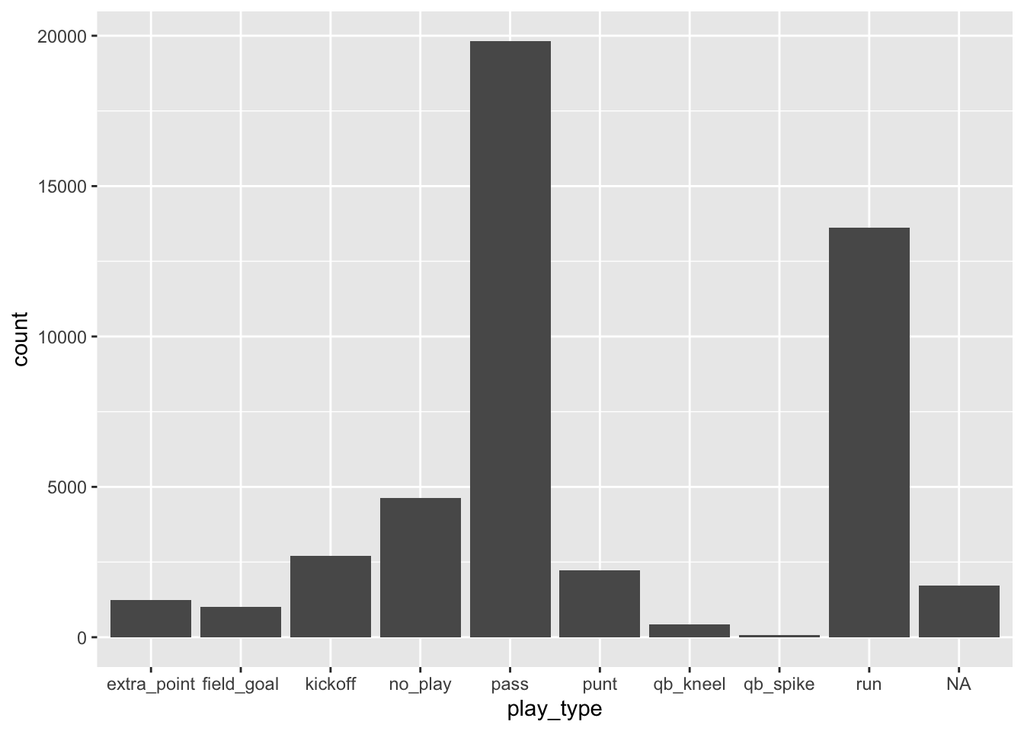

```r
## Bar Chart that counts number of plays of different play types
pbp %>%
  ggplot(aes(x= play_type)) + geom_bar()
```

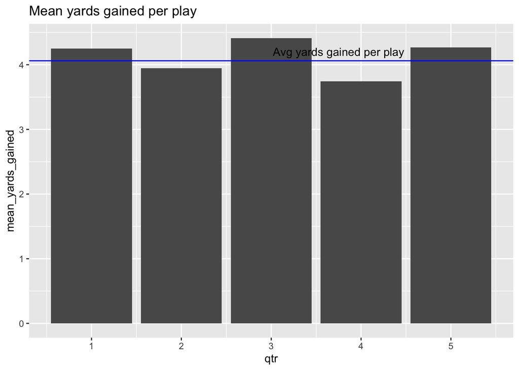

```r
## Graph of average yards gained per play in each quarter
pbp %>% group_by(qtr) %>% summarise(mean_yards_gained = mean(yards_gained, na.rm = TRUE)) %>%
  ggplot(aes(x= qtr, y = mean_yards_gained)) + geom_bar(stat = "identity") +
  labs(title = "Mean yards gained per play") +
  geom_hline(yintercept = mean(pbp$yards_gained, na.rm = TRUE), color = "blue") +
  annotate("text", label = "Avg yards gained per play", x = 3.75, y = 4.2)
```

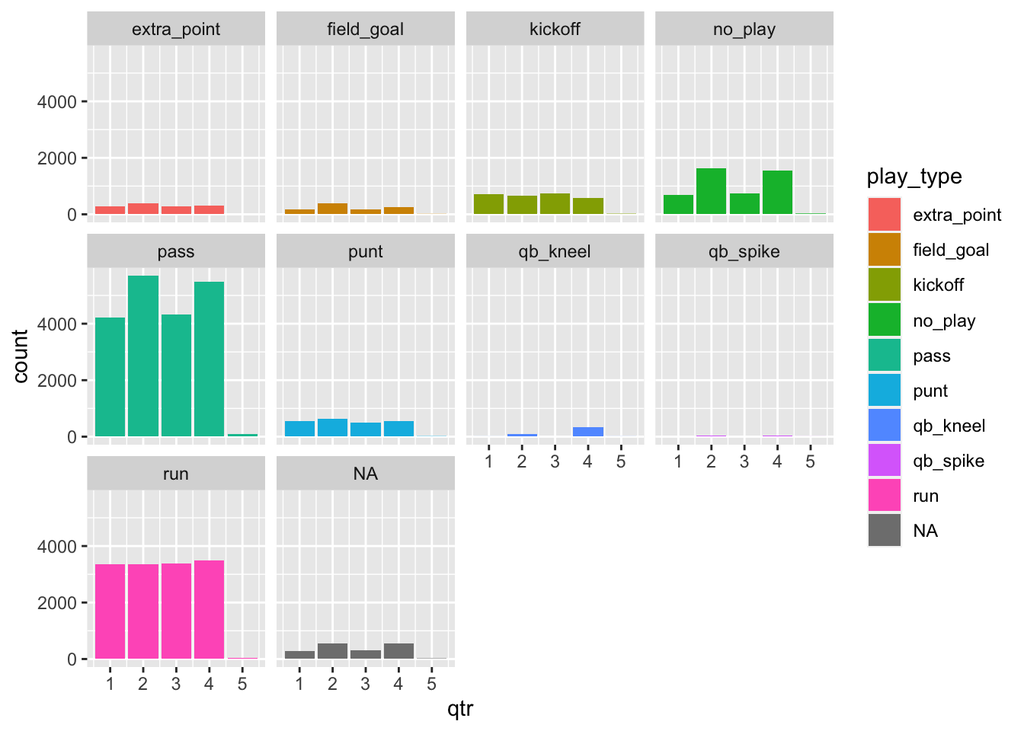

```r
## Distribution of play types by quarter
pbp %>%
  ggplot(aes(x= qtr, fill = play_type)) + geom_bar() + facet_wrap(~play_type)
```

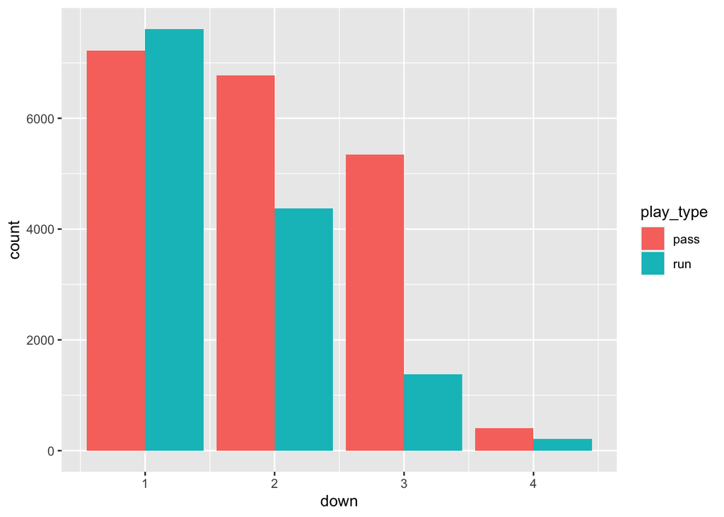

```r
## Graph of pass vs run plays broken down by down
pbp %>%
  filter(play_type == "pass" | play_type == "run") %>%
  ggplot(aes(x= down, fill = play_type)) + geom_bar(position="dodge")
```

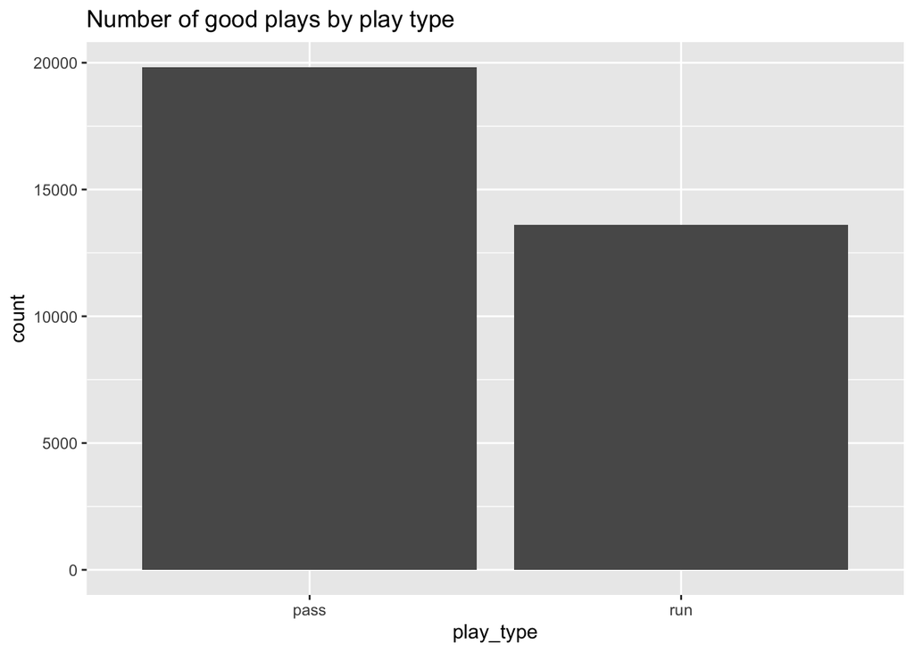

```r
## Graph showing number of good plays broken down by pass vs run plays
pbp %>%
  filter(play_type == "pass" | play_type == "run") %>%
  ggplot(aes(x= play_type, fill = good_play)) + geom_bar(position="dodge") +
  labs(title = "Number of good plays by play type")
```

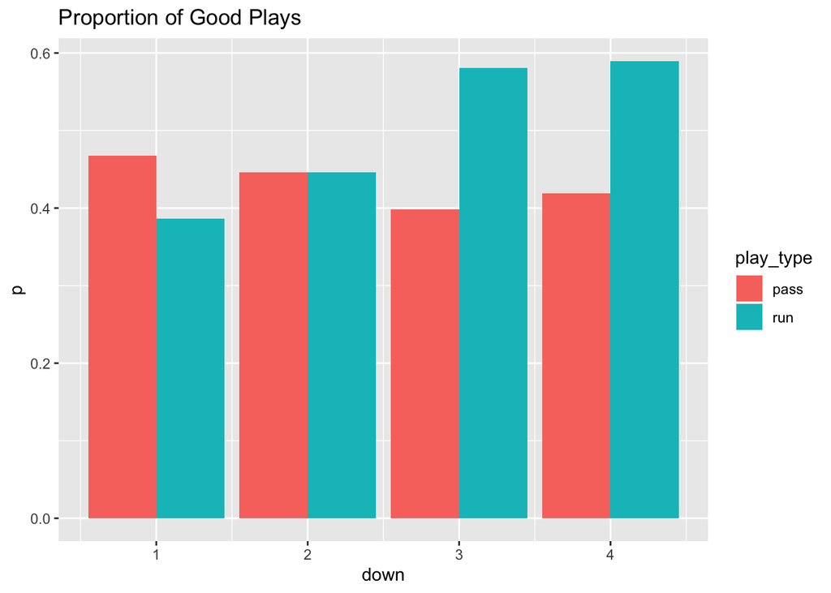

```r
## Graph of proportion of good plays grouped by down & play type
pbp %>%
  filter(play_type == "pass" | play_type == "run", is.na(good_play) == FALSE, down != 5) %>%
  group_by(down, play_type) %>%
  summarise(p = sum(good_play) / length(good_play)) %>%
  ggplot(aes(x = down, y = p, fill = play_type)) +
  geom_bar(stat= "identity", position = "dodge") +
  labs(title = "Proportion of Good Plays")
```

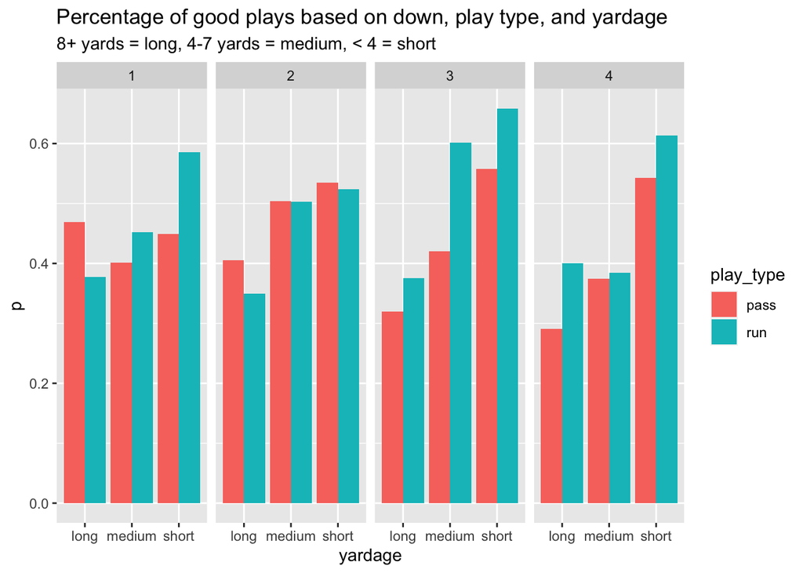

```r
## Graph of proportion of good plays grouped by down, play type, and yardage
pbp %>%
  filter(play_type == "pass" | play_type == "run", is.na(good_play) == FALSE, down != 5) %>%
  group_by(yardage, play_type, down) %>%
  summarise(p = sum(good_play) / length(good_play)) %>%
  ggplot(aes(x= yardage, y = p, fill = play_type)) +
  geom_bar(stat = "identity", position = "dodge") +
  facet_grid(~down) +
  labs(title = "Percentage of good plays based on down, play type, and yardage",
       subtitle = "8+ yards = long, 4-7 yards = medium, < 4 = short")
```

## Hypothesis Testing:

After exploring the data a bit, I became curious about whether there is a difference in the proportion of passing plays between the 1st and 2nd half of the game. To do this, I will complete a paired t-test that measures the difference of each team’s 1st and 2nd half proportion.

Null Hypothesis: HO: D = 0; Half has no effect on the proportion of passing plays Alternative Hypothesis: Ha: D != 0; Half does have an effect on the proportion of passing plays

```r
team_quarter_pct_passing_first_half = pbp %>%
  filter(qtr == 1 | qtr == 2) %>%
  group_by(posteam) %>%
  filter(play_type != "no_play", is.na(play_type) != TRUE) %>%
  summarise(pct_passing = sum(pass) / length(pass))

team_quarter_pct_passing_second_half = pbp %>%
  filter(qtr == 3 | qtr == 4) %>%
  group_by(posteam) %>%
  filter(play_type != "no_play", is.na(play_type) != TRUE) %>%
  summarise(pct_passing = sum(pass) / length(pass))

t.test(team_quarter_pct_passing_first_half$pct_passing, team_quarter_pct_passing_second_half$pct_passing,
       paired = TRUE, alternative = "two.sided")
```

```
##
##  Paired t-test
##
## data:  team_quarter_pct_passing_first_half$pct_passing and team_quarter_pct_passing_second_half$pct_passing
## t = 0.038568, df = 31, p-value = 0.9695
## alternative hypothesis: true difference in means is not equal to 0
## 95 percent confidence interval:
##  -0.01793267  0.01862397
## sample estimates:
## mean of the differences
##            0.0003456508
```

Based on the results of the paired t test, there is no evidence to suggest that the proportion of passing plays changes based on which half it is. The p-value os 0.9695 is extremely high. The mean difference was 0.0003456508, which is very close to 0. The 95% Confidence interval was (-0.01793267, 0.01862397). Based on these, I believe that it’s safe to say that the true mean difference is extremely close to 0.

## Classification Model:

I plan to attempt to predict if a play is a run or pass play based on different variables in the data set. I believe this could be a very useful tool for a defensive coordinator to utilize. If successful, a coordinator would be better equipped to call defensive audibles if analytics teams were able to quickly make predictions based on certain game scenarios.

```r
## Building train and test data sets

classifier_data_set = pbp %>% filter(play_type == "pass" | play_type == "run", is.na(down) != TRUE)

n = length(classifier_data_set$play_id)

train_rows = sample(n, n/2)

train = classifier_data_set[train_rows,]
test = classifier_data_set[-train_rows,]

## Training the classifier

## pass is 1 if pass play, 0 if not
log_m1 = glm(pass ~ wp + ydstogo + down + game_seconds_remaining, data = train, family = "binomial")
summary(log_m1)
```

```
##
## Call:
## glm(formula = pass ~ wp + ydstogo + down + game_seconds_remaining,
##     family = "binomial", data = train)
##
## Deviance Residuals:
##     Min       1Q   Median       3Q      Max
## -3.1794  -1.1085   0.6138   0.9925   2.0481
##
## Coefficients:
##                          Estimate Std. Error z value Pr(>|z|)
## (Intercept)            -1.410e+00  8.753e-02 -16.111   <2e-16 ***
## wp                     -1.451e+00  5.991e-02 -24.223   <2e-16 ***
## ydstogo                 1.307e-01  5.506e-03  23.738   <2e-16 ***
## down                    8.454e-01  2.512e-02  33.653   <2e-16 ***
## game_seconds_remaining -3.833e-05  1.622e-05  -2.363   0.0181 *
## ---
## Signif. codes:  0 '***' 0.001 '**' 0.01 '*' 0.05 '.' 0.1 ' ' 1
##
## (Dispersion parameter for binomial family taken to be 1)
##
##     Null deviance: 22544  on 16658  degrees of freedom
## Residual deviance: 20345  on 16654  degrees of freedom
## AIC: 20355
##
## Number of Fisher Scoring iterations: 4
```

```r
log_probs1 = predict(log_m1, newdata = test, type = "response")
log_p1 = ifelse(log_probs1 > 0.5, 1, 0)
c_matrix1 = table(log_p1 == test$pass)
c_matrix1
```

```
##
## FALSE  TRUE
##  5555 11105
```

```r
log_m2 = glm(pass ~ wp + ydstogo + down, data = train, family = "binomial")
summary(log_m2)
```

```
##
## Call:
## glm(formula = pass ~ wp + ydstogo + down, family = "binomial",
##     data = train)
##
## Deviance Residuals:
##     Min       1Q   Median       3Q      Max
## -3.1898  -1.1160   0.6149   0.9934   2.0438
##
## Coefficients:
##              Estimate Std. Error z value Pr(>|z|)
## (Intercept) -1.475871   0.082963  -17.79   <2e-16 ***
## wp          -1.457404   0.059760  -24.39   <2e-16 ***
## ydstogo      0.130588   0.005504   23.73   <2e-16 ***
## down         0.846470   0.025112   33.71   <2e-16 ***
## ---
## Signif. codes:  0 '***' 0.001 '**' 0.01 '*' 0.05 '.' 0.1 ' ' 1
##
## (Dispersion parameter for binomial family taken to be 1)
##
##     Null deviance: 22544  on 16658  degrees of freedom
## Residual deviance: 20350  on 16655  degrees of freedom
## AIC: 20358
##
## Number of Fisher Scoring iterations: 4
```

```r
log_probs2 = predict(log_m2, newdata = test, type = "response")
log_p2 = ifelse(log_probs2 > 0.5, 1, 0)
c_matrix2 = table(log_p2 == test$pass)
c_matrix2
```

```
##
## FALSE  TRUE
##  5542 11118
```

```r
log_m3 = glm(pass ~ down + ydstogo + td_prob + fg_prob + posteam,
             data = train, family = "binomial")
summary(log_m3)
```

```
##
## Call:
## glm(formula = pass ~ down + ydstogo + td_prob + fg_prob + posteam,
##     family = "binomial", data = train)
##
## Deviance Residuals:
##     Min       1Q   Median       3Q      Max
## -2.8504  -1.1501   0.6466   1.0285   2.3226
##
## Coefficients:
##              Estimate Std. Error z value Pr(>|z|)
## (Intercept) -1.171665   0.151287  -7.745 9.59e-15 ***
## down         0.692969   0.028768  24.088  < 2e-16 ***
## ydstogo      0.102853   0.006026  17.067  < 2e-16 ***
## td_prob     -1.975575   0.184294 -10.720  < 2e-16 ***
## fg_prob      0.794389   0.218816   3.630 0.000283 ***
## posteamATL   0.387168   0.136329   2.840 0.004512 **
## posteamBAL  -0.501561   0.131079  -3.826 0.000130 ***
## posteamBUF  -0.300990   0.133956  -2.247 0.024644 *
## posteamCAR   0.247883   0.135569   1.828 0.067480 .
## posteamCHI  -0.129506   0.135929  -0.953 0.340718
## posteamCIN   0.191128   0.136645   1.399 0.161896
## posteamCLE  -0.031987   0.137336  -0.233 0.815829
## posteamDAL  -0.038803   0.133195  -0.291 0.770801
## posteamDEN  -0.132857   0.138453  -0.960 0.337264
## posteamDET  -0.051230   0.137544  -0.372 0.709551
## posteamGB    0.006255   0.132904   0.047 0.962459
## posteamHOU   0.064134   0.133692   0.480 0.631427
## posteamIND  -0.393967   0.138137  -2.852 0.004344 **
## posteamJAX   0.055943   0.137905   0.406 0.684990
## posteamKC    0.090154   0.131891   0.684 0.494258
## posteamLA    0.013295   0.135363   0.098 0.921761
## posteamLAC   0.134025   0.139422   0.961 0.336405
## posteamLV   -0.206886   0.139874  -1.479 0.139119
## posteamMIA   0.189357   0.138511   1.367 0.171596
## posteamMIN  -0.291013   0.132930  -2.189 0.028581 *
## posteamNE   -0.058999   0.132651  -0.445 0.656488
## posteamNO    0.048591   0.135317   0.359 0.719527
## posteamNYG   0.256046   0.139959   1.829 0.067336 .
## posteamNYJ  -0.084380   0.138465  -0.609 0.542264
## posteamPHI  -0.003338   0.131615  -0.025 0.979766
## posteamPIT  -0.128882   0.139780  -0.922 0.356509
## posteamSEA  -0.118681   0.131191  -0.905 0.365656
## posteamSF   -0.319360   0.131810  -2.423 0.015398 *
## posteamTB    0.066652   0.135748   0.491 0.623430
## posteamTEN  -0.348151   0.133615  -2.606 0.009170 **
## posteamWAS  -0.120366   0.141054  -0.853 0.393472
## ---
## Signif. codes:  0 '***' 0.001 '**' 0.01 '*' 0.05 '.' 0.1 ' ' 1
##
## (Dispersion parameter for binomial family taken to be 1)
##
##     Null deviance: 22544  on 16658  degrees of freedom
## Residual deviance: 20686  on 16623  degrees of freedom
## AIC: 20758
##
## Number of Fisher Scoring iterations: 4
```

```r
log_probs3 = predict(log_m3, newdata = test, type = "response")
log_p3 = ifelse(log_probs3 > 0.5, 1, 0)
c_matrix3 = table(log_p3 == test$pass)
c_matrix3
```

```
##
## FALSE  TRUE
##  5790 10870
```

```r
best_logistic_model_prop = 11095 / (11095 + 5565)
best_logistic_model_prop
```

```
## [1] 0.6659664
```

```r
library("pROC")
ROC = roc(test$pass, log_p2)
```

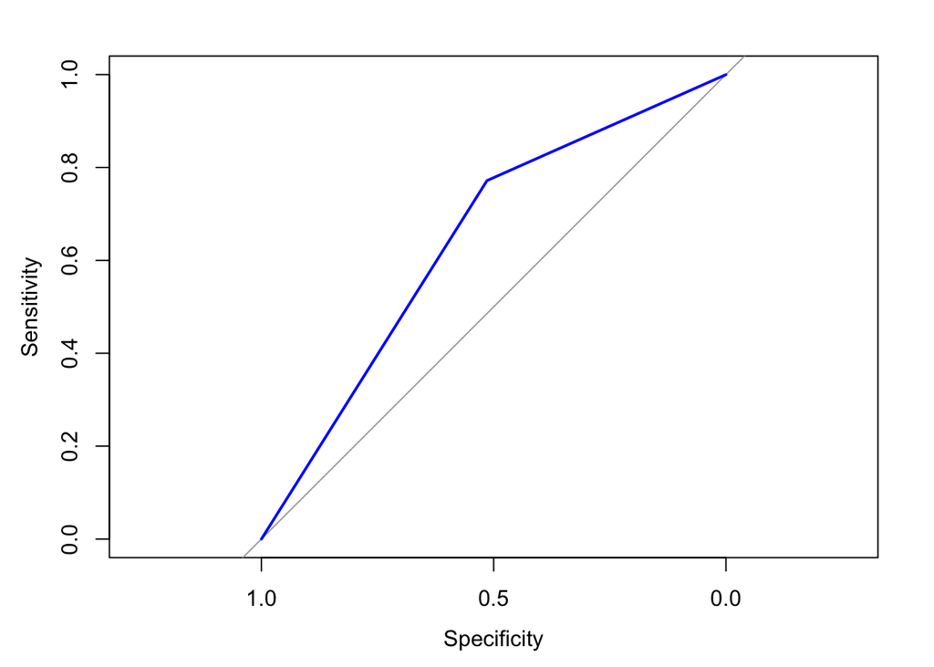

```r
plot(ROC, col = "blue")
```

```r
auc(ROC)
```

```
## Area under the curve: 0.643
```

It would be interesting to see how my algorithm would do if there were other variables used that I do not have access to. I believe it would be beneficial for NFL teams to build similar machine learning algorithms that are trained on a data set that is more specific to the type of players and team they’d be facing. The algorithm might be better at predicting against certain QBs, for example like Patrick Mahomes or Lamar Jackson. Defensive coordinators could find this very useful as they’d be better equipped to make better decisions regarding defensive scheme, substitutions, and plays if they have can make good predictions of the next play type.

```r
first_down = pbp %>% filter(down == 1) %>%
  filter(play_type == "pass" | play_type == "run") %>%
  mutate(pass = ifelse(play_type == "pass", 1, 0))
second_down = pbp %>% filter(down == 2) %>%
  filter(play_type == "pass" | play_type == "run") %>%
  mutate(pass = ifelse(play_type == "pass", 1, 0))
third_down = pbp %>% filter(down == 3) %>%
  filter(play_type == "pass" | play_type == "run") %>%
  mutate(pass = ifelse(play_type == "pass", 1, 0))
fourth_down = pbp %>% filter(down == 4) %>%
  filter(play_type == "pass" | play_type == "run" | play_type == "field_goal" | play_type == "punt") %>%
  mutate(pass = ifelse(play_type == "pass", 1, 0))

first_down$play_type = as.factor(first_down$play_type)
second_down$play_type = as.factor(second_down$play_type)
third_down$play_type = as.factor(third_down$play_type)
fourth_down$play_type = as.factor(fourth_down$play_type)


first_down_pct_passing = first_down %>%
  group_by(posteam) %>%
  summarize(pct_passing = sum(pass) / length(pass)) %>%
  mutate("down" = 1)

second_down_pct_passing = second_down %>%
  group_by(posteam) %>%
  summarize(pct_passing = sum(pass)/ length(pass)) %>%
  mutate("down" = 2)

third_down_pct_passing = third_down %>%
  group_by(posteam) %>%
  summarize(pct_passing = sum(pass)/ length(pass)) %>%
  mutate("down" = 3)

fourth_down_pct_passing = fourth_down %>%
  group_by(posteam) %>%
  summarize(pct_passing = sum(pass)/ length(pass)) %>%
  mutate("down" = 4)

fourth_down_pct_running = fourth_down %>%
  mutate("run" = ifelse(play_type == "run",1,0)) %>%
  group_by(posteam) %>%
  summarize(pct_running = sum(run)/ length(run)) %>%
  mutate("down" = 4)

fourth_down_aggressiveness = merge(fourth_down_pct_passing, fourth_down_pct_running, by = "posteam")
head(fourth_down_aggressiveness)
```

```
##   posteam pct_passing down.x pct_running down.y
## 1     ARI  0.11475410      4  0.04918033      4
## 2     ATL  0.14678899      4  0.04587156      4
## 3     BAL  0.17171717      4  0.11111111      4
## 4     BUF  0.06766917      4  0.07518797      4
## 5     CAR  0.12698413      4  0.06349206      4
## 6     CHI  0.12598425      4  0.03937008      4
```

[figure not shown]

```r
## Getting rid of team logos of old teams
logos = teams_colors_logos %>% select(team_abbr, team_logo_espn) %>%
  filter(team_abbr != "LAR", team_abbr != "SD", team_abbr != "STL", team_abbr != "OAK")

## Visualizing fourth down aggressiveness of teams
ggplot(fourth_down_aggressiveness, aes(x= pct_passing, y = pct_running)) +
  geom_image(aes(image = logos$team_logo_espn), size = 0.05, asp = 16 / 9) +
  geom_hline(yintercept = mean(fourth_down_aggressiveness$pct_running)) +
  geom_vline(xintercept = mean(fourth_down_aggressiveness$pct_passing)) +
  annotate("text", x=.17, y=.1, label = "Aggressive on 4th down \n w/ pass & run") +
  annotate("text", x=.07, y=.1, label = "Aggressive on 4th down \n w/ run") +
  annotate("text", x=.05, y=.04, label = "Not Aggressive \n on 4th down \n w/ either pass or run") +
  annotate("text", x=.18, y=.03, label = "Aggressive on 4th down \n w/ pass") +
  labs(title = "Fourth Down Aggressiveness",
       subtitle = "Percent of 4th down plays that were passing or running plays")
```

```r
x1= merge(first_down_pct_passing, second_down_pct_passing, by = "posteam")
x2= merge(x1, third_down_pct_passing, by = "posteam")
x3= merge(x2, fourth_down_pct_passing, by = "posteam")
colnames(x3) = c("Team", "first_down_passing", "Down1", "second_down_passing", "Down2 ",
                 "third_down_passing", "Down3", "fourth_down_passing", "Down4")


x3 = x3 %>% select(Team, first_down_passing, second_down_passing, third_down_passing, fourth_down_passing)
head(x3)
```

```
##   Team first_down_passing second_down_passing third_down_passing
## 1  ARI          0.5183486           0.5921450          0.8256410
## 2  ATL          0.5855131           0.7014085          0.8398058
## 3  BAL          0.3894325           0.4792746          0.6237624
## 4  BUF          0.4916667           0.5231214          0.7260870
## 5  CAR          0.5427975           0.6592179          0.8454106
## 6  CHI          0.5186916           0.6023055          0.8139535
##   fourth_down_passing
## 1          0.11475410
## 2          0.14678899
## 3          0.17171717
## 4          0.06766917
## 5          0.12698413
## 6          0.12598425
```

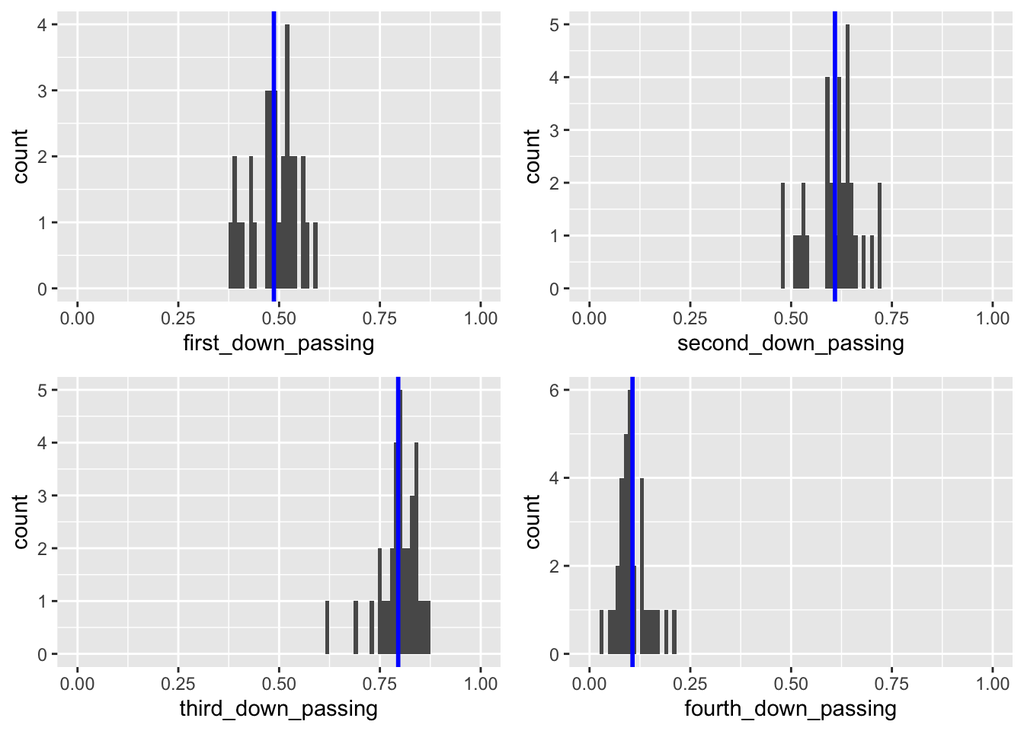

```r
g1= ggplot(data = x3) + geom_histogram(aes(x = first_down_passing), binwidth = .01) +
  geom_vline(xintercept = mean(first_down_pct_passing$pct_passing), col = "blue", size = 1) +
  scale_x_continuous(limits = c(0,1))

g2= ggplot(data = x3) + geom_histogram(aes(x = second_down_passing), binwidth = .01) +
  geom_vline(xintercept = mean(second_down_pct_passing$pct_passing), col = "blue", size = 1) +
  scale_x_continuous(limits = c(0,1))

g3= ggplot(data = x3) + geom_histogram(aes(x = third_down_passing), binwidth = .01) +
  geom_vline(xintercept = mean(third_down_pct_passing$pct_passing), col = "blue", size = 1)+
  scale_x_continuous(limits = c(0,1))

g4= ggplot(data = x3) + geom_histogram(aes(x = fourth_down_passing), binwidth = .01) +
  geom_vline(xintercept = mean(fourth_down_pct_passing$pct_passing), col = "blue", size = 1)+
  scale_x_continuous(limits = c(0,1))

library(gridExtra)
grid.arrange(g1,g2,g3,g4, nrow=2)
```